# L22_DS_Nonnormal slides

## AERSP 597 - Machine Learning in Aerosapce Engineering

## Lecture 22, Dynamical System: Nonnormality

### Instructor: Daning Huang

$$ \newcommand\norm[1]{{\left\lVert #1 \right\rVert}} \newcommand{\bR}{\mathbb{R}} \newcommand{\vf}{\mathbf{f}} \newcommand{\vg}{\mathbf{g}} \newcommand{\vv}{\mathbf{v}} \newcommand{\vw}{\mathbf{w}} \newcommand{\vx}{\mathbf{x}} \newcommand{\vy}{\mathbf{y}} \newcommand{\vA}{\mathbf{A}} \newcommand{\vB}{\mathbf{B}} \newcommand{\vU}{\mathbf{U}} \newcommand{\vV}{\mathbf{V}} \newcommand{\vW}{\mathbf{W}} \newcommand{\vX}{\mathbf{X}} \newcommand{\vtf}{\boldsymbol{\phi}} \newcommand{\vty}{\boldsymbol{\psi}} \newcommand{\vtF}{\boldsymbol{\Phi}} \newcommand{\vtS}{\boldsymbol{\Sigma}} \newcommand{\vtL}{\boldsymbol{\Lambda}} \newcommand{\cF}{\mathcal{F}} \newcommand{\cK}{\mathcal{K}} $$

## TODAY: Dynamical System - II

- Finite-time stability analysis
  - Transient growth
  - Maximum gain
  - Resolvent analysis

### Example problem and code:

- Available [here](https://github.com/smanist/ML_in_AERSP_Supp).

### References:

- [Schmid2009](https://fluids.ac.uk/files/resources/1_Schmid.pdf) P. Schmid, Nonmodal stability analysis, 2009; or a more formal paper version [Schmid2014](https://asmedigitalcollection.asme.org/appliedmechanicsreviews/article/66/2/024803/395151/Analysis-of-Fluid-Systems-Stability-Receptivity)
- [AIAAJ2017](https://arc.aiaa.org/doi/pdf/10.2514/1.J056060) Modal Analysis of Fluid Flows: An Overview, 2017
- [AIAAJ2020](https://arc.aiaa.org/doi/pdfplus/10.2514/1.J058462) Modal Analysis of Fluid Flows: Applications and Outlook, 2020

## Stability analysis (Nonnormal)

The example from previous lecture suggests that we need to differentiate **two types of stability**:

- Linear stability: we are interested in the **minimum** critical parameter above which a specific initial condition of **infinitesimal** amplitude grows exponentially
- Energy stability: we are interested in the **maximum** critical parameter below which a general initial condition of **finite** amplitude decays monotonically

### Strategies for transient behaviors

Take a closer look at the response in terms of "energy" $$ E(t)=\norm{x(t)}^2 $$

#### Continuing to use the previous example 2D linear system

The eigenvectors and eigenvalues of $A$ are $$ V=\begin{bmatrix} \cos(\pi/4-\delta) & \cos(\pi/4+\delta) \\ \sin(\pi/4-\delta) & \sin(\pi/4+\delta) \end{bmatrix},\quad \Lambda=\begin{bmatrix} -0.1 & 0 \\ 0 & -0.2 \end{bmatrix} $$

> So the linear system should be stable, at least when $t\rightarrow \infty$

But when $\delta\rightarrow 0$, $V$ becomes ill-conditioned.

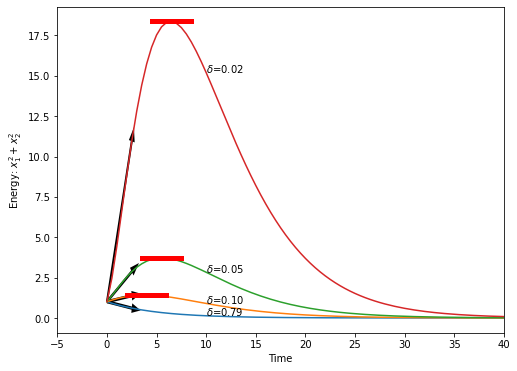

```python
X0 = [1, 0.1]
ds = [np.pi/4, 0.1, 0.05, 0.02]
pltEnergy(X0, ds)
```

- The energy certainly decay to zero over long time, since the system is linearly stable
- Black arrows: The initial growth rate of energy gives a good estimate how high the energy may go
  - This leads to the **Transient growth analysis**
- Red bars: The maximum growth in energy gives a more direct characterization for stability
  - This leads to the **Maximum gain analysis**
  - w.r.t. either initial conditions or inputs

### Some preparations

Consider a linear system, $$ \dot{x} = Ax + f,\quad x(0)=x_0 $$ When $f=0$, the solution is (by matrix exponential) $$ x(t) = \exp(At)x_0 $$ When $x_0=0$, the solution is (by convolution) $$ x(t) = \int_0^t \exp((\tau-t)A)f(\tau)d\tau $$

> We will first focus on the zero-input case

Using the concept of energy, define the stability in the sense of *the growth of perturbation energy over time*, based on the matrix exponential. $$ G(t) = \max_{x_0}\frac{\norm{x(t)}^2}{\norm{x_0}^2} = \max_{x_0}\frac{\norm{\exp(At)x_0}^2}{\norm{x_0}^2} = \norm{\exp(At)}^2 $$ which represents the **maximum possible** amplification of perturbation energy over all initial conditions.

> Recall that a matrix norm $\norm{A}$ can be "induced" by a vector norm (typically L2), $\norm{A}=\max_x \frac{\norm{Ax}}{\norm{x}}$

If we diagonalize $A=V\Lambda V^{-1}$, then $$ G(t) = \norm{\exp(At)}^2 = \norm{V\exp(\Lambda t)V^{-1}}^2 $$

> Again, if we follow linear stability analysis, then we would deduce the behavior of $G(t)$ from $\exp(\Lambda t)$, or simply $\Lambda$, **only**. But this is insufficient to characterize $G(t)$ as shown in the previous example.

Let's think in terms of the following bounds of $G(t)$, $$ \exp(2\lambda_\max t) \leq G(t) \leq \norm{V}^2\norm{V^{-1}}^2\exp(2\lambda_\max t) $$

> The second inequality is a property of matrix norm $\norm{ABC}\leq\norm{A}\norm{B}\norm{C}$

If the system is linearly stable, i.e., $Re(\lambda)<0$

- When $t\rightarrow\infty$, both sides decay to zero, so $G(t)$ is certainly zero.
- But before that, would $G(t)$ do something else?
  - Or, would $G(t)$ go to (close-to-)infinity in **finite time**?
- Note that term $\norm{V}\norm{V^{-1}}$ - looking familiar? It is the condition number of $V$, $\kappa(V)$.
  - Recall we have argued before that when $\kappa(A)$ is large, it would be difficult to numerically solve linear system of equations $Ax=b$.
- Now, if $V$ is "well-behaved", so that $\kappa(V)\approx 1$, then $$ G(t) \approx \exp(2\lambda_\max t) $$ i.e. the energy amplification is governed by the least stable eigenvalue, $\lambda_\max$.
- But if $V$ is "badly-behaved", so that $\kappa(V)\gg 1$, then $$ \exp(2\lambda_\max t) \leq G(t) \leq \kappa(V)^2\exp(2\lambda_\max t) $$ i.e. the energy amplification is governed by $\lambda_\max$ **only for large times**.

Now we introduce the concept of **normality** of a matrix $A$.

- $A$ is normal iff it is diagonalizable and its different eigenspaces are orthogonal to each other
  - In other words, $A=V\Lambda V^H$, i.e. $V$ is unitary, $V^{-1}=V^H$
  - Then $\kappa(V)=1$
  - Eigenvalue analysis captures the **entire** dynamics
- Otherwise $A$ is non-normal
  - Characterized by non-orthogonal eigenvectors
  - $\kappa(V)$ can be large
  - Eigenvalue analysis captures the **asymptotic** dynamics, but not the short-time behavior

### Transient short-term analysis

Consider the rate of change for $E(t)$, considering that $\dot x=Ax$ $$ \frac{dE(t)}{dt} = (\dot x^H) x + x^H (\dot x) = (x^HA^H)x + x^HAx = 2Re((Ax)^H x) $$

> The last step is because $(x^HA^H)x$ and $x^HAx$ are scalars and complex conjugates of each other - so only the real part remains

With the form of $dE(t)/dt$, some people found it compelling to define the **numerical range** $$ F(A) = \left\{ z\ |\ z=\frac{(Ax)^H x}{x^Hx} \right\} $$ i.e. the (scaled) relative growth rate of energy, normalized by the initial energy

> If you have heard of Rayleigh's quotient, then $F(A)$ is essentially all possible values of the quotient.

Things we need to know about numerical range:

- It is convex;
- It contains the spectrum of $A$, i.e. all of its eigenvalues;
- It is the convex hull of the spectrum, if $A$ is normal.

Also, we define the maximum real number in the numerical range as the **numerical abscissa**, $\alpha(A)$

- Alternatively $$\alpha(A)=Re[\lambda_\max(A+A^H)/2]$$ Think about why.

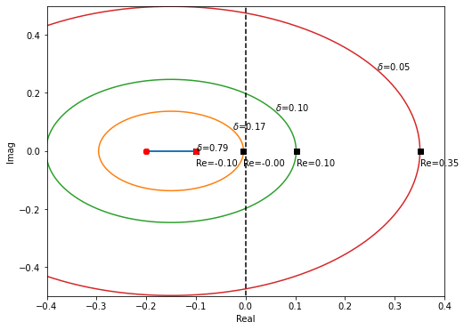

```python
ds = [np.pi/4, 0.175, 0.1, 0.05]  # Note at \delta=0.175, \alpha(A)~=0
pltNumRange(ds)
```

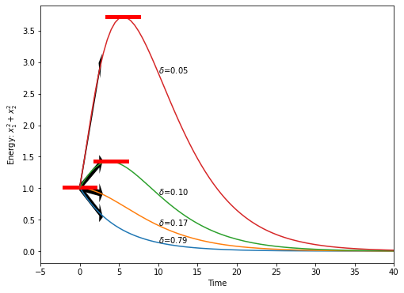

```python
X0 = [1, 0.1]
ds = [np.pi/4, 0.175, 0.1, 0.05]  # As expected at \delta=0.175, energy growth~=0
pltEnergy(X0, ds, awid=0.1)
```

Let's think about the meaning of $\alpha(A)$ and the initial condition $x_0^*$ that generates $\alpha(A)$

- If $\alpha(A)>0$, then if the system starts from $x_0^*$, the system energy will **grow**
- In short time the growth can be high and the system may show some **instability**
- This is true even when all the eigenvalues are on the left half plane (i.e. stable when $t\rightarrow\infty$)

Think again the matrix normality

- If $A$ is normal, $\alpha(A)=Re(\lambda_\max(A))$, then long-term stability **equals to** short-term stability
- If $A$ is non-normal, it is possible that $\alpha(A) \gg Re(\lambda_\max(A))$, then long/short-term analysis **differ**

### Maximum-gain analysis: Initial conditions

Consider a non-normal system that initially undergoes fast growth and eventually decay to zero. It is of interest to estimate the maximum amplitude of the growth, or the **maximum gain** of the system $$ G_\max = \max_{t\geq 0}\norm{\exp(tA)} $$

- If the amplitude is low, we are probably still in a linearizable region and the system is still stable over all
- If the amplitude is high, then the linearization itself might break - i.e. the long-term behavior becomes meaningless

#### For a given time

- Starting from zero-input solution $$ x(t) = \exp(At)x_0 $$
- What is the $x_0$ that maximizes the energy amplification at a given time $t^*$?

We essentially want $$ \tilde{G}_\max(t^*) = \max_{x_0} \frac{\norm{\exp(t^*A)x_0}}{\norm{x_0}} = \norm{\exp(t^*A)} $$ Then the SVD of $\exp(t^*A)=U\Sigma V^H$ solves the problem

- The first right singular vector $v_1$ defines the (unit) $x_0$
- The first left singular vector $u_1$ defines the maximum state $x$ at $t=t^*$
- The first singular value $\sigma_1$ is the maximum gain

> Also, the minimum $\sigma$ corresponds to the minimum gain of the system, i.e. we cannot get lower than that!

[figure not shown]

```python
delta = 0.05   # This is a highly non-normal case, and we get a pretty large gain (and disparity in gains)
ti = 14
pltInitGain(delta, ti)
```

#### For any time

We would like **maximum gain** of the system $$ G_\max = \max_{t\geq 0}\norm{\exp(tA)} = \max_{t\geq 0}\tilde{G}_\max(t) $$ Consider the Laplace Transform of the solution $$ \tilde{x}(s) = \int_0^\infty \exp(-st)\exp(tA)x_0 dt = (sI-A)^{-1}x_0 $$ Here we can define the **resolvent operator** $$ H(s) = (sI-A)^{-1} \equiv \int_0^\infty \exp(-st)\exp(tA) dt $$

Using inequalities for integrals, we can find the lower bound of $G_\max$ $$ \norm{H(s)} \leq \int_0^\infty \norm{\exp(-st)} \norm{\exp(tA)} dt \leq \frac{1}{Re(s)} \max_{t\geq 0}\norm{\exp(tA)} $$ or $$ \max_{Re(s)} Re(s)\norm{H(s)} \leq G_\max $$ The lower bound is also called the **Kreiss constant**, $K(A)$.

> $K(A)\geq 1$; and $K(A)=1$ if $A$ is normal - think about why?

It turns out one can also find an upper bound using $K(A)$, so that $$ K(A)\leq G_\max \leq e n K(A) $$ where $e=\exp(1)$ and $n$ is dimension of $A$.

> So Kreiss constant is very useful for characterizing the max gain.

#### Side note

One may also find another upper bound for $G_\max$ from complex analysis $$ \exp(tA) = \frac{1}{2\pi i} \oint_\Lambda \exp(zt) (zI-A)^{-1} dz \leq \frac{1}{2\pi} \oint_\Lambda \norm{(zI-A)^{-1}} |dz| $$ Then $$ G_\max \leq \frac{1}{2\pi} \oint_\Lambda \norm{H(s)} |ds| $$

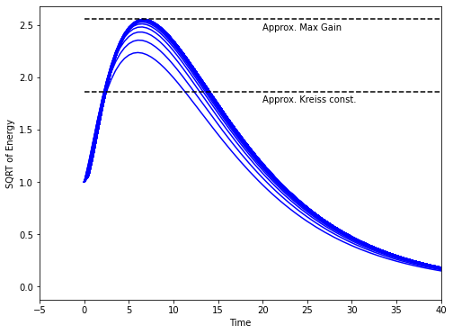

```python
delta = 0.05
ts = range(1,80)
pltGainSweep(delta, ts)  # So Kreiss constant does provide an estimate of the lower bound of gains
```

### Maximum-gain analysis: Forced response

Similarly, we can think about the zero-initial-condition solution $$ x(t) = \int_0^t \exp((\tau-t)A)f(\tau)d\tau $$

- What is the (harmonic) input $f$ that maximizes the energy amplification over time?

Assume $f(t)=\hat{f}\exp(i\omega t)$ and do Fourier Transform $$ \hat{x} = (i\omega I-A)^{-1} \hat{f} $$ Then we essentially want $$ G_\max = \max_{\hat{f}} \frac{\norm{(i\omega I-A)^{-1} \hat{f}}}{\norm{\hat{f}}} $$ Again the SVD gives the solution. Let $(i\omega I-A)^{-1}=U(\omega)\Sigma(\omega) V(\omega)^H$, then

- $V(\omega)$ gives the forcing and $U(\omega)$ gives the output
- $\Sigma(\omega)$ gives the gain

> The range of $\sigma(\omega)$'s give the range of possible gains at the given frequency $\omega$

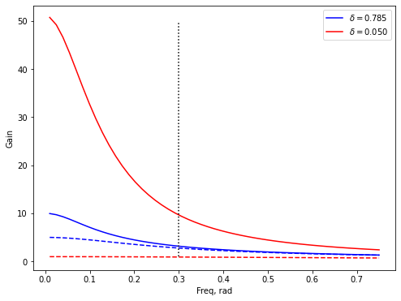

```python
W = np.linspace(0.01, 0.75, 51)
ds = [np.pi/4, 0.05]
pltSVDsweep(W, ds)
```

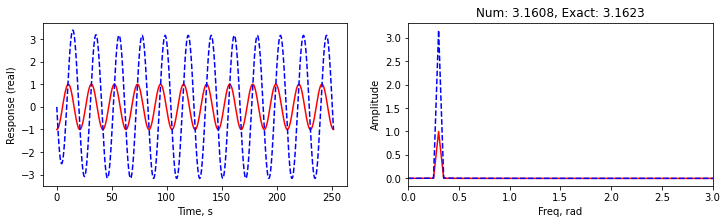

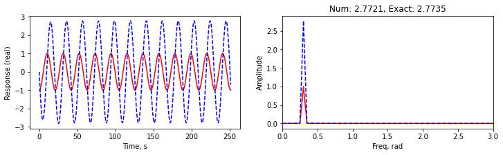

```python
S = makeSys2D(0.785)    # The normal system behaves "normally", no extremely large gains
ugv = frMIMO(S, [0.3], ifFull=True)
pltGainResp(S, 0.3, ugv, 0)
pltGainResp(S, 0.3, ugv, 1)
```

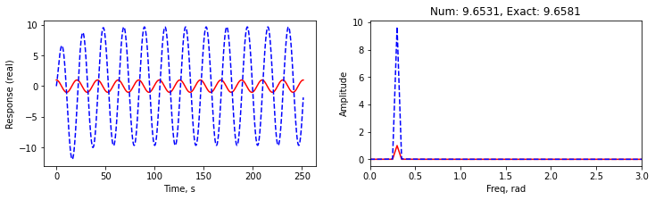

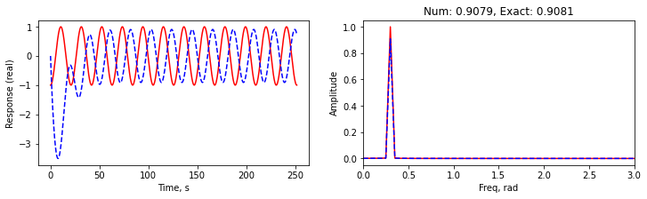

```python
S = makeSys2D(0.05)    # But things get crazy in non-normal systems
ugv = frMIMO(S, [0.3], ifFull=True)
pltGainResp(S, 0.3, ugv, 0)
pltGainResp(S, 0.3, ugv, 1)
```

Think about the example more, $$ \norm{(i\omega I-A)^{-1}} = \norm{V(i\omega I-\Lambda)^{-1}V^{-1}} \leq \frac{\kappa(V)}{\norm{i\omega I-\Lambda}} $$

- For a normal system, $\kappa(V)=1$, and the norm becomes infinite (if no damping) if the forcing frequency coincides with the spectrum - then we have resonance, *as expected*.
- For non-normal system, it is possible to have **pseudo-resonance**, i.e. large response to external forcing, even though the forcing frequency is far from the actual spectrum.

### Alternative view of $\norm{H(s)}$

Consider the eigenvalue problem of $A$, perturbed by another matrix $E$, $\norm{E}=\epsilon$ is small $$ (A+E)u=\lambda u,\quad \mbox{or}\quad (A-\lambda I)u = -Eu $$ Using the matrix norm inequality $$ \begin{align} \norm{(A-\lambda I)u} &= \norm{-Eu} \leq \norm{E}\norm{u} = \epsilon\norm{u} \\ \epsilon^{-1} &\leq \norm{u}/\norm{(A-\lambda I)u} = \norm{(A-\lambda I)^{-1}} \end{align} $$ Or $$ \norm{H(s)} \geq \epsilon^{-1} $$ In other words,

- The resolvent contours represent the eigenvalue distribution of all possible perturbed $A$'s
  - Therefore the contours are also called **pseudospectrum**
- If the eigenvalues change a lot with a small $\epsilon$, i.e. are sensitive to perturbations, then the system is likely to be non-normal

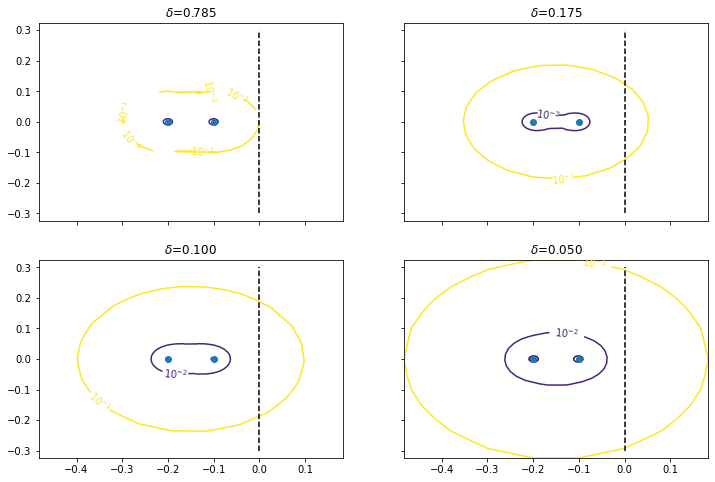

```python
# note how as non-normality increases, the pseudospectrum extrudes into positive side,
# which indicates the potential (easier) destabilization of the system.
pltPseudoSpec([np.pi/4, 0.175, 0.1, 0.05], range(-5, 0))
```

#### Spectrum and Pseudospectrum

One can define the **spectrum** of $A$, which is equivalent to eigenvalues $$ \sigma(A) = \left\{ z\in\mathbb{C}\ |\ (zI-A)^{-1} \mbox{ does not exist} \right\} $$

> Here we are following the common notation in literature, but be careful to differentiate from singular values of $A$.

Then pseudospectrum can be thought of the generalization of eigenvalues $$ \sigma_\epsilon(A) = \left\{ z\in\mathbb{C}\ |\ \norm{(zI-A)^{-1}} > \epsilon^{-1} \right\} $$

So that we formally have $$ \lim_{\epsilon\rightarrow 0}\sigma_\epsilon(A)=\sigma(A) $$ since as $\epsilon\rightarrow 0$, $\norm{(zI-A)^{-1}} > \infty$, meaning $(zI-A)^{-1}$ does not exist.

In fact, there is a theorem, stating that the intersection of $\sigma_\epsilon(A)$ of all $\epsilon$ gives $\sigma(A)$ $$ \cap_{\epsilon>0}\sigma_\epsilon(A)=\sigma(A) $$

With the above connection, one can also have the following equivalent definitions $$ \sigma_\epsilon(A) = \left\{ z\in\mathbb{C}\ |\ \exists \norm{E}<\epsilon,\ z\in\sigma(A+E) \right\} $$ $$ \sigma_\epsilon(A) = \left\{ z\in\mathbb{C}\ |\ \exists v,\ \norm{(zI-A)v}=\epsilon \norm{v} \right\} $$

And one can also define the abscissa of the pseudospectrum, similar to numerical abscissa, as $$ \alpha_\epsilon(A) = \max Re(\sigma_\epsilon(A)) $$ Then this connects to the Kreiss constant again $$ K(A) = \max_{\epsilon>0} \frac{\alpha_\epsilon(A)}{\epsilon} $$

### Summary

To characterize a linear system, esp. in terms of stability, now we know

- Linear stability analysis: Real parts of eigenvalues
- Transient growth analysis: Numerical range and abscissa
- Maximum gain analysis: Resolvent operator and its SVD; Pseudospectrum and the Kreiss constant

> In the next lecture let's revisit Dynamic Mode Decomposition in terms of resolvent analysis

#### Side note

Finally, the analysis using resolvent operator can extend to more complex dynamical systems, such as

- stochastic forcing
- parameter and mean-flow uncertainty
- time-periodic and generally time-dependent flow
- nonlinear perturbation dynamics
- multiple inhomogeneous directions/complex geometry using Lyapunov analysis, Floquet theory, adjoint analysis, and so on.

See [Schmid2009] for more details.

## Properties of Nonnormal matrices (Optional)

Summary based on [this post](https://nhigham.com/2020/11/24/what-is-a-nonnormal-matrix/) by Nick Higham.

This discussion is from a pure linear algebra perspective, different from the previous discussion based on linear systems.

### Definitions

$A$ is **normal** if it is **unitarily diagonalizable**: $A = QDQ^H$

- $D$ diagonal, having the eigenvalues
- $Q$ unitary, representing a complete set of orthonormal eigenvectors
- The condition number $\kappa(Q)=\norm{Q} \norm{Q^{-1}}=\norm{Q} \norm{Q^H}=1$

> $A$ is normal iff it is diagonalizable and its different eigenspaces are orthogonal to each other

For a general diagonalizable matrix, $A = XDX^{-1}$, the condition number $\kappa(X)$ can be arbitrarily large, which may pose an issue in numerical computation.

> Yet, one should also keep the non-diagonlizable matrices in mind

For example, in 2D, normal matrices can only be of the following two forms, $$ \begin{bmatrix} a & b \\ b & c \end{bmatrix}, \begin{bmatrix} a & b \\ -b & a \end{bmatrix} $$

And one example type of non-normal matrix is $$ \begin{bmatrix} a & b \\ 0 & a \end{bmatrix} $$

Alternatively, we can define a **commutator**, which is always Hermitian, $$ C = AA^H- A^HA $$ and apparently when $A$ is normal $C=0$.

When $A$ is non-normal - general properties of $C$

- $C$ has zero trace, because the diagonal cancels out; then the eigenvalues sum to zero
- But if $C$ is nonzero, there should be at least two different nonzero eigenvalues (so they cancel out and make trace zero)
- And the rank of $C$ is at least 2.

### Measurement of non-normality

There are many ways to do so. In the previous sections, we have seen numerical range/abscissa.

#### Using Triangularization

While $A$ is not necessarily unitarily diagonalizable, it always has a **Schur decomposition**, $$ A = QTQ^H $$ where $Q$ is unitary and $T=D+M$ is upper triangular. $D$ is still the eigenvalue matrix, and $M$ is a strict upper triangular matrix.

When $A$ is normal, certainly $M=0$ and Schur decomposition reduces to eigendecomposition.

- Then $\norm{M}_F$ is a natural measure of how far $A$ is from being normal
- Formally, one can use the following equivalent form, given by Henrici in 1960s $$ \nu(A) = \norm{M}_F \equiv \biggl( \norm{A}_F^2 - \sum_{j=1}^n |\lambda_j|^2 \biggr)^{1/2}. $$

It is bounded as $$ \frac{\norm{C}_F}{4\norm{A}_2} \le \nu(A) \le \Bigl( \frac{n^3-n}{12} \Bigr)^{1/4} \norm{C}_F^{1/2}. $$

#### Using Frobenius norm

Alternatively, one can define the distance to normality by "brutal force" as the minimum "effort" $E$ required to make $A$ normal, $$ d(A) = \min \left\{ \norm{E}_F: A+E \in \mathbb{C}^{n\times n} \mbox{ is normal} \right\} $$ See [Higham1988](https://www.maths.manchester.ac.uk/~higham/narep/narep161.pdf) for algorithms for $d(A)$.

It is bounded as $$ \frac{\nu(A)}{n^{1/2}} \le d(A) \le \nu(A) $$

#### Using condition number

Considering only the diagonalizable matrices, $A=X\Lambda X^{-1}$, one may simply use the condition number of $X$ to quantify the non-normality. Specifically, we consider the L2-norm condition number $$ \kappa_2(X) = \norm{X}\norm{X^{-1}} $$

But since in the diagonalization process, $X$ is not unique, we pick the one with the smallest $\kappa_2$, i.e., $$ \kappa_2(X) = \min\left\{ \kappa_2(Y): A = YDY^{-1}, D \mbox{ diagonal} \right\}. $$

Next we show a series of bounds relevant to $\kappa_2(X)$ and observe that when $\kappa_2(X)=1$, i.e. when $A$ is normal, all the bounds **simplify to equalities**. This makes $\kappa_2(X)$ a good indicator of non-normality.

Notations